# Reproducible Research Week 2 Project

## Loading and preprocessing the data

Read activity data in to R, total the number of steps taken each day, and convert date column from factor to date variable type

```r
activitydata <- read.csv("./activity.csv")
activitydata <- transform(activitydata, date = as.Date(date))
activitytable <- aggregate(activitydata$steps, by=list(activitydata$date), sum)
colnames(activitytable) <- c("date", "TotalStepsTaken")
```

## Mean and median number of steps taken each day

Report mean and median of total steps taken each day

```r
mean(activitytable$TotalStepsTaken, na.rm=TRUE)
```

```
## [1] 10766.19
```

```r
median(activitytable$TotalStepsTaken, na.rm=TRUE)
```

```
## [1] 10765
```

Create a histogram of the total number of steps taken each day

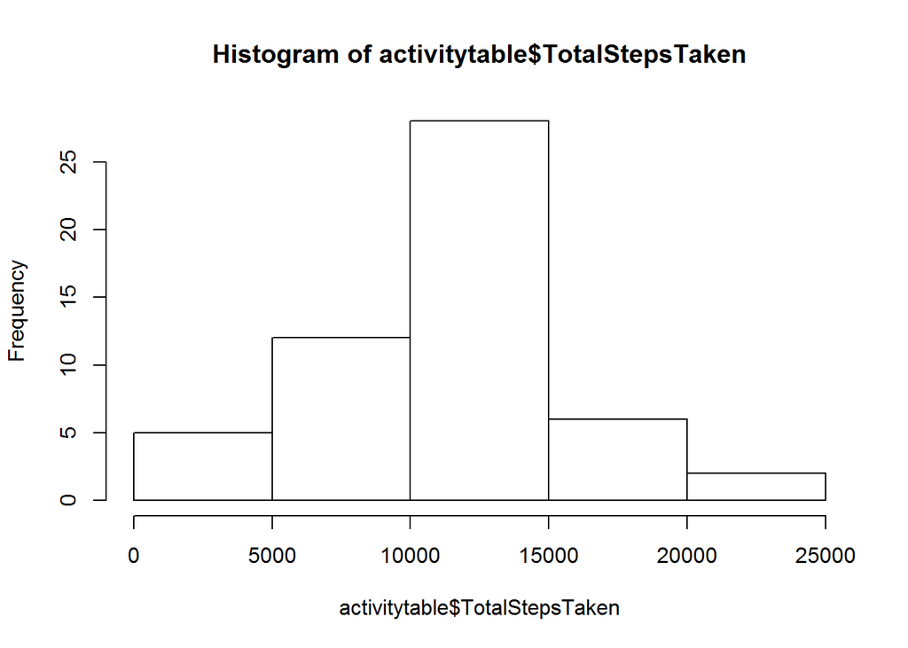

```r
hist(activitytable$TotalStepsTaken)
```

## Average daily activity pattern

Create a time series plot of the average number of steps taken during each interval

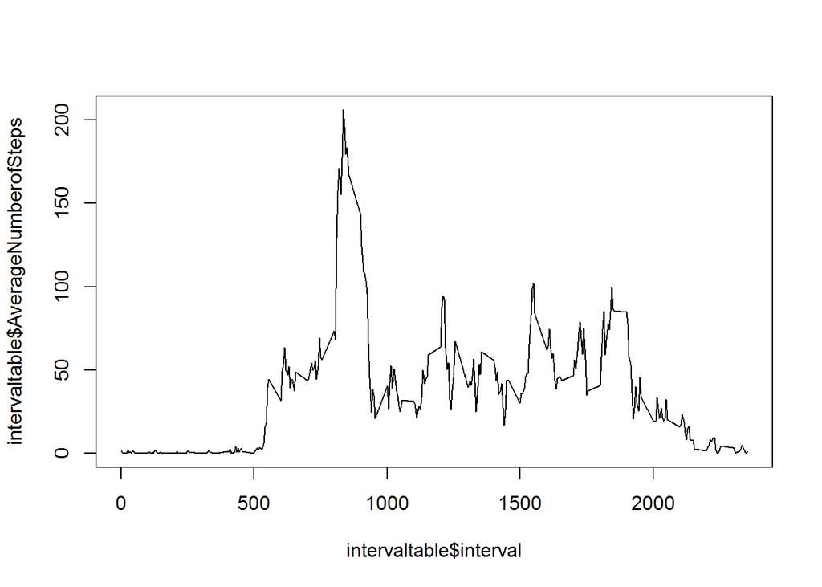

```r
intervaltable <- aggregate(activitydata$steps, by=list(activitydata$interval),
                           mean, na.rm=TRUE)
colnames(intervaltable) <- c("interval", "AverageNumberofSteps")
plot(intervaltable$interval, intervaltable$AverageNumberofSteps, type="l")
```

Identify interval with the highest average number of steps

```r
intervaltable[intervaltable[,2]==max(intervaltable$AverageNumberofSteps), 1]
```

```
## [1] 835
```

## Input missing values

Calculate number of rows with missing data

```r
table(is.na(activitydata$steps))
```

```
##
## FALSE  TRUE
## 15264  2304
```

Substitute missing data with average number of steps taken, rounded down, for the recorded interval

```r
activitydata[is.na(activitydata$steps),1] <- floor(intervaltable[which(activitydata[is.na(activitydata$steps),3]==intervaltable[1]), 2])
```

Create new table and histogram detailing the total number of steps taken according to the updated data set

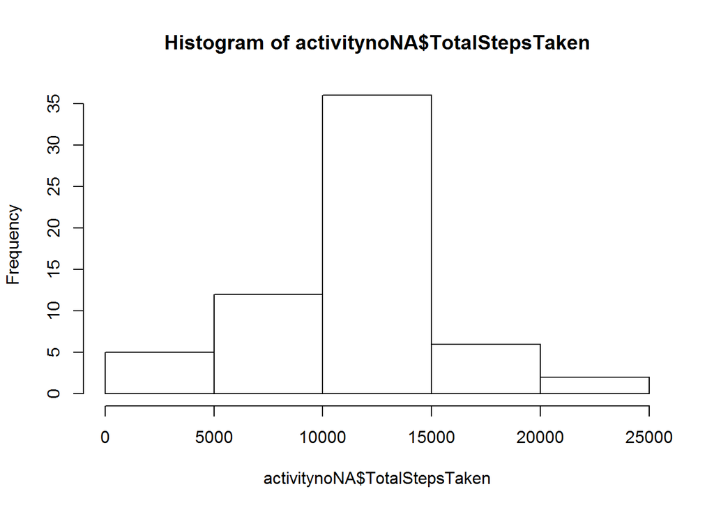

```r
activitynoNA <- aggregate(activitydata$steps, by=list(activitydata$date), sum)
colnames(activitynoNA) <- c("date", "TotalStepsTaken")
hist(activitynoNA$TotalStepsTaken)
```

Calculate mean and median number of steps taken each day for the new data set

```r
mean(activitynoNA$TotalStepsTaken)
```

```
## [1] 10749.77
```

```r
median(activitynoNA$TotalStepsTaken)
```

```
## [1] 10641
```

As a result of replacing the missing values with the average number of steps taken during the recorded interval, the mean and median number of steps taken each day both slightly decreased.

## Differences between weekdays and weekendsset

Create a new factor variable called DayType that is assigned the value “Weekend” if the weekdays() function returns the value “Saturday” or “Sunday” or is assigned the value “Weekday”

```r
activitydata$DayType <- factor(NA, c("Weekday","Weekend"))
i=1
for (i in 1:nrow(activitydata)){
      if(weekdays(activitydata[i,2])=="Sunday"||
         weekdays(activitydata[i,2])=="Saturday"){
            activitydata[i,4]<-"Weekend"}

      else {activitydata[i,4] <- "Weekday"}}
```

Calculate average number of steps taken for each interval during a “Weekday” and a “Weekend”

```r
DayTypeTable <- aggregate(activitydata$steps,
                          by=list(activitydata$DayType,activitydata$interval),
                          mean)
colnames(DayTypeTable) <- c("DayType", "Interval", "AverageStepsTaken")
```

Create a time series plot of the average number of steps taken during each measured interval for “Weekday” days and “Weekend” days

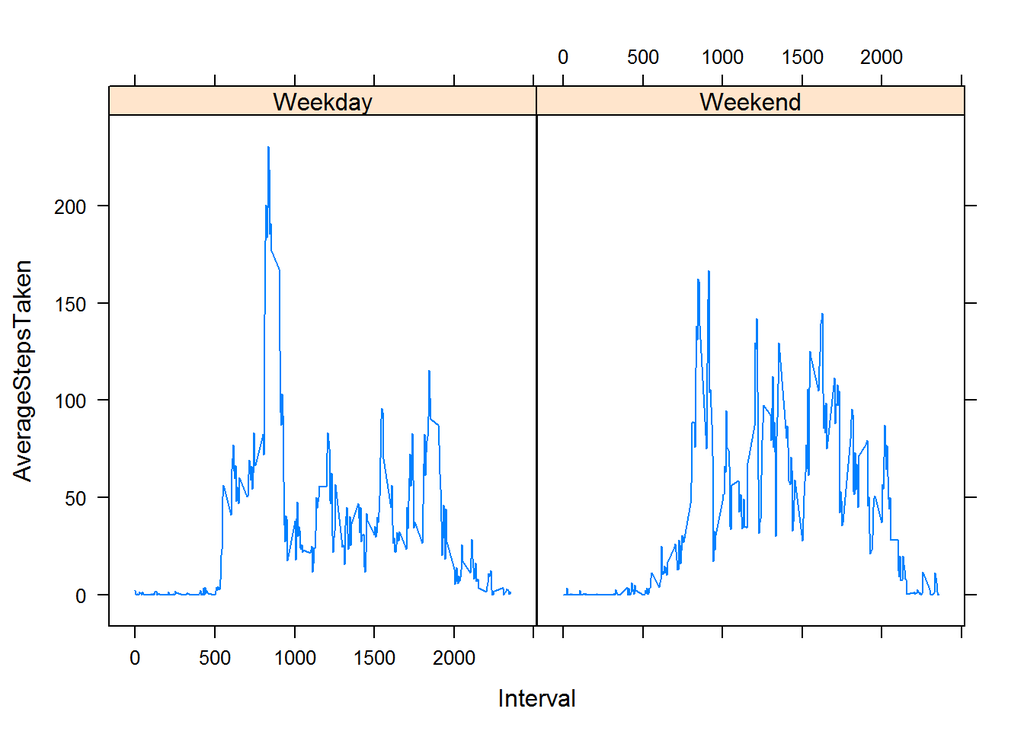

```r
    library(lattice)
    xyplot(AverageStepsTaken ~ Interval | DayType, data=DayTypeTable, type="l")
```